# Cartograflow

Filtering Matrix with ordinal distance criterion for Thematic Flow Mapping

Cartograflow, 2020

2020-05-17

This vignette of `Cartograflow` is dedicated to filtering an Origin-Destination matrix with an ordinal distance matrix.

This matrix describes a neighborhood defined by a number (k) of boundaries to be crossed in order to reach a place of destination from a place of origin

The aim is to map local flows that are either adjacent or located at low (k).

## Main function

**flowcontig**

– `flowcontig()` compute an *ordinal distance* matrix from spatial features (area). The result is a matrix of adjacency or k-contiguity of the ODs.

- `background` is the areal spatial features ;
- `code` is the spatial features codes ;
- `k` is to enter the number (k:1,2,…,k) of the contiguity matrix to be constructed : if (k=1), ODs places are adjacent, then the flow have to cross only 1 boundary, else (k=k) ODs places are distant from n borders ;
- `algo` is the algorithm to use for ordinal distance calculation (also Default is “automatic” for “Dijkstra’s”) ;

Notice that the function automatically returns the maximum (k) number of the spatial layer.

## Useful additional functions for a complete analysis

**flowreduct**

– `flowreduct()` is to reduce the flow dataset regarding another matrix, e.g. distances travelled.

- `metric` is the metric of the distance matrix : *continuous* (e.g. for meters) or *ordinal* (e.g. for adjacency).

**flowmap**

– `flowmap()` is to plot flows as segments or arrows, by acting on the following arguments: - `filter` is to filter or not flow’s information or features - `threshold` is used to set the filtering level of the flows when filter=“True” - `taille` is the value of the width of the flow feature - `a.head` is the arrow head parameter (in, out, in and out) - `a.length` is the length of the edges of the arrow head (in inches) - `a.angle` is the angle from the shaft of the arrow to the edge of the arrow head - `a.col` is the arrow’s color - `plota` is to add spatial features as map background to the flows’s plot - `add` is to allow to overlay flow features on external spatial features background

## **1. Load datasets**

**Flow dataset**

```r
# Load Statistical information

data<-read.csv("./data/MOBPRO_ETP.csv",
                header=TRUE,
                sep=";",
                stringsAsFactors=FALSE,
                encoding="UTF-8",
                dec=".",
                check.names=FALSE)

data$Fij<-as.numeric(data$Fij)
tabflow<-data
```

**Geographical dataset**

```r
# Load a list of geographic codes
CODE<-read.csv2("./data/MOBPRO_ETP.csv",
                header=TRUE,
                   sep=";",
                   stringsAsFactors=FALSE,
                   encoding="UTF-8",
                   dec=".",
                   check.names=FALSE
                )

# Load a spatial shape map background of geo codes
map<-st_read("./data/MGP_TER.shp")
```

## **2. Compute adjacency matrix and reduces flow matrix**

Example is for neighbouring areas which share a common boundary (k=1)

**2.1. Computes the neighbouring graph**

```r
library(igraph)
## Neighbouring graph (ordre 1)
graph_ckij_1<-flowcontig(bkg=map, code="EPT_NUM", k=1, algo = "automatic")
```

```
## [1] "ordre max = 3"
```

```r
#ordre max = "3"
```

**2.2. Flow reduction according to the neighbouring graph**

Reducing flow matrix by the neighbouring graph (k=1)

```r
library(rlang)

head(tabflow)
```

```
##    i   j    Fij count
## 1 T1  T1 291058   351
## 2 T1 T10   8297    43
## 3 T1 T11   3889    13
## 4 T1 T12  17064    77
## 5 T1  T2  12163    52
## 6 T1  T3  32682    55
```

```r
head(graph_ckij_1)
```

```
##     i  j ordre
## 1  T3 T2     1
## 2 T12 T2     1
## 3  T1 T2     1
## 4  T2 T3     1
## 5  T4 T3     1
## 6  T1 T3     1
```

```r
reduc_k1<-flowreduct(tabflow,
                  graph_ckij_1,
                  metric = "ordinal")


head(reduc_k1)
```

```
##    i   j  flow ordre.c NA
## 1 T1 T10  8297      43  1
## 2 T1 T12 17064      77  1
## 3 T1  T2 12163      52  1
## 4 T1  T3 32682      55  1
## 5 T1  T4 81129     134  1
## 6 T1  T5 16622      63  1
```

## **3. Flowmap according to a neighbouring graph**

**3.1. flows between adjacent areas** Use (k=1) parameter

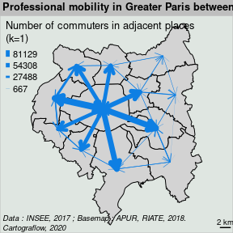

```r
# Graphic parameters
knitr::opts_chunk$set(fig.width=6, fig.height=6)
par(mar=c(0,0,1,0))
extent <- c(2800000, 1340000, 6400000, 4800000)
resolution<-150

# Overlay a spatial background
par(bg = "NA")

# Add the corresponding background
plot(st_geometry(map), col = NA, border=NA, bg="#dfe6e1")
plot(st_geometry(map), col = "light grey", add=TRUE)


#Flowmap : flow travelled between border areas

flowmap(tab=reduc_k1,
        fij="flow",origin.f = "i",destination.f = "j",
        bkg = map,code="EPT_NUM",nodes.X="X",nodes.Y = "Y",
        filter=TRUE,
        taille=8,
        a.head = 1,
        a.length = 0.11,
        a.col="#0e7fe3",
        add=TRUE
        )

# Map Legend
legendPropLines(pos="topleft",
                title.txt="Number of commuters in adjacent places\n(k=1)",
                title.cex=0.8,
                cex=0.5,
                values.cex= 0.7,
                var=c(min(reduc_k1$flow),max(reduc_k1$flow)),
                col="#0e7fe3",
                lwd=8,
                frame = FALSE,
                values.rnd = 0
                )

# Map cosmetic
layoutLayer(title = "Professional mobility in Greater Paris between 1-neighbouring municipalities",
            author = "Cartograflow, 2020",
            sources = "Data : INSEE, 2017 ; Basemap : APUR, RIATE, 2018.",
            scale = 2,
            tabtitle = FALSE,
            frame = TRUE,
            col = "grey",
            coltitle ="black")
```

**3.2. flows between non adjacent areas** Use for example (k=3) parameter

```r
library(igraph)

## Neighbouring graph (Max(k)=3)
graph_ckij_3<-flowcontig(bkg=map, code="EPT_NUM",k=3)
```

```
## [1] "ordre max = 3"
```

```r
# Flow reduction

head(tabflow)
```

```
##    i   j    Fij count
## 1 T1  T1 291058   351
## 2 T1 T10   8297    43
## 3 T1 T11   3889    13
## 4 T1 T12  17064    77
## 5 T1  T2  12163    52
## 6 T1  T3  32682    55
```

```r
reduc_k3<-flowreduct(tabflow,
                  graph_ckij_3,
                  metric = "ordinal")

head(reduc_k3)
```

```
##    i   j  flow ordre.c NA
## 1 T1 T10  8297      43  1
## 2 T1 T11  3889      13  2
## 3 T1 T12 17064      77  1
## 4 T1  T2 12163      52  1
## 5 T1  T3 32682      55  1
## 6 T1  T4 81129     134  1
```

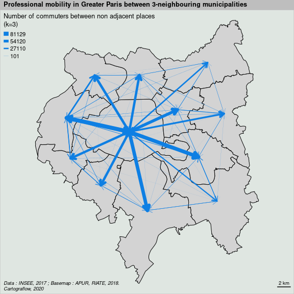

```r
# Graphic parameters
knitr::opts_chunk$set(fig.width=6, fig.height=6)
par(mar=c(0,0,1,0))
extent <- c(2800000, 1340000, 6400000, 4800000)
resolution<-150

# Overlay a spatial background
par(bg = "NA")

# Add the corresponding background
plot(st_geometry(map), col = NA, border=NA, bg="#dfe6e1")
plot(st_geometry(map), col = "light grey", add=TRUE)


#Flowmap : flow travelled between border areas

flowmap(tab=reduc_k3,
        fij="flow",origin.f = "i",destination.f = "j",
        bkg = map,code="EPT_NUM",nodes.X="X",nodes.Y = "Y",
        filter=TRUE,
        taille=8,
        a.head = 1,
        a.length = 0.11,
        a.col="#0e7fe3",
        add=TRUE
        )

# Map Legend
legendPropLines(pos="topleft",
                title.txt="Number of commuters between non adjacent places\n(k=3)",
                title.cex=0.8,
                cex=0.5,
                values.cex= 0.7,
                var=c(min(reduc_k3$flow),max(reduc_k3$flow)),
                col="#0e7fe3",
                lwd=8,
                frame = FALSE,
                values.rnd = 0
                )


# Map cosmetic
layoutLayer(title = "Professional mobility in Greater Paris between 3-neighbouring municipalities",
            author = "Cartograflow, 2020",
            sources = "Data : INSEE, 2017 ; Basemap : APUR, RIATE, 2018.",
            scale = 2,
            tabtitle = FALSE,
            frame = TRUE,
            col = "grey",
            coltitle ="black")
```

## **4. Flowmap reducing and filtering according to ordinal matrix**

Use the contiguity parameter **(k)** in association to the **threshold flowmap parameter** to map above-average flows that occur between adjacent areas

**4.1 Computes filter criteria** Use for example (k=1) parameter and threshold = mean.

```r
#Computes k=1
library(igraph)

## Neighbouring graph k=1
graph_ckij_1<-flowcontig(bkg=map, code="EPT_NUM",k=1)
```

```
## [1] "ordre max = 3"
```

```r
# Flow reduction
reduc_k1<-flowreduct(tabflow,
                  graph_ckij_1,
                  metric = "ordinal")
head(reduc_k1)
```

```
##    i   j  flow ordre.c NA
## 1 T1 T10  8297      43  1
## 2 T1 T12 17064      77  1
## 3 T1  T2 12163      52  1
## 4 T1  T3 32682      55  1
## 5 T1  T4 81129     134  1
## 6 T1  T5 16622      63  1
```

```r
#Extract the mean
reduc_k1_mean<-mean(reduc_k1$flow)

mean<-mean(tabflow$Fij)

# mean value of reduc_k1_mean =18591
# mean value of tabflow =13220
```

**4.2 Flow mapping**

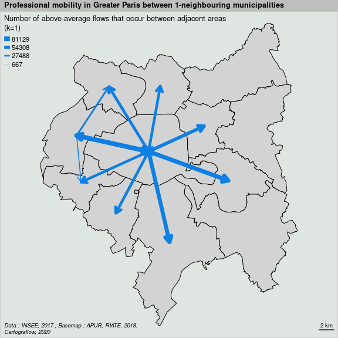

```r
# Graphic parameters
knitr::opts_chunk$set(fig.width=6, fig.height=6)
par(mar=c(0,0,1,0))
extent <- c(2800000, 1340000, 6400000, 4800000)
resolution<-150

# Overlay a spatial background
par(bg = "NA")

# Add the corresponding background
plot(st_geometry(map), col = NA, border=NA, bg="#dfe6e1")
plot(st_geometry(map), col = "light grey", add=TRUE)


#Flowmap : flow travelled between border areas

flowmap(tab=reduc_k1,
        fij="flow",origin.f = "i",destination.f = "j",
        bkg = map,code="EPT_NUM",nodes.X="X",nodes.Y = "Y",
        filter=TRUE,
        threshold = 13220, #reduc_k1 ean value is 18591 ; tabflow mean value is 13220
        taille=8,
        a.head = 1,
        a.length = 0.11,
        a.col="#0e7fe3",
        add=TRUE
        )


# Map Legend
legendPropLines(pos="topleft",
                title.txt="Number of above-average flows that occur between adjacent areas\n(k=1)",
                title.cex=0.8,
                cex=0.5,
                values.cex= 0.7,
                var=c(min(reduc_k1$flow),max(reduc_k1$flow)),
                col="#0e7fe3",
                lwd=8,
                frame = FALSE,
                values.rnd = 0
                )


# Map cosmetic
layoutLayer(title = "Professional mobility in Greater Paris between 1-neighbouring municipalities",
            author = "Cartograflow, 2020",
            sources = "Data : INSEE, 2017 ; Basemap : APUR, RIATE, 2018.",
            scale = 2,
            tabtitle = FALSE,
            frame = TRUE,
            col = "grey",
            coltitle ="black")
```

## See also

– cartograflow_general.html  
– cartograflow_distance.html  
– cartograflow_concentration.html  
– cartograflow_contiguity.hmtl

## Reference

– Bahoken Francoise (2016), Programmes pour R/Rtudio annexés, in : *Contribution à la cartographie d’une matrix de flux*, Thèse de doctorat, Université Paris 7, pp. 325-346. URL : https://halshs.archives-ouvertes.fr/tel-01273776, pp. 480-520.